# Investigation of PM2.5 concentration in Aotizhongxin

Hrishi Singh

25/04/2021

## Summary

In this report we investigate data on the air quality in Beijing in the period from 2014 to 2016. The aim is to see which meteorological variables or pollutants influence the concentration of PM2.5 and by how much. This report uses exploratory methods like plotting histograms, boxplots, scatter graphs and hypothesis tests. We find that PM10 concentration influences PM2.5 concentration the most out of all the other pollutants. Furthermore the variability of PM2.5 concentration when raining appears to be significantly less than when it is not.

## Introduction

From 2014 to 2016, Beijing experienced chronic air pollution. The main pollutants were fine particulate matter, and PM2.5 in particular. PM2.5 consists of airborne particles with aerodynamic diameters of less than 2.5 µm. Evidence shows that exposure to PM2.5 can cause lung morbidity, serious respiratory and cardiovascular diseases, and even death. We know PM2.5 concentration is highly influenced by meteorological variables. So our aim in performing this statistical analysis is to identity which variables cause the greater influence on PM2.5 concentration. We will specifically looking at how the PM2.5 concentration at Aotizhongxin is influenced by variables like rainfall, temperature and dew point. This report is important as determining the influence of meteorological variables and other pollutants upon PM2.5 concentration may help reduce it in the future which would beneficial as the health ramification from exposure to PM2.5 can be incredibily severe.

## Methods

In this report, summary statistics are used throughout to summarize and provide information about the sample data.

Histograms are used throughout this report to predominately visual the distribution of the data.

QQ plots are used in this report to confirm whether sets of data follows a specific distribution. If all the points approximately fall along the line in the QQ plot, then the data does follow that distribution. For example to see whether the temperature at Aotizhongxin follows a normal distribution.

Not only are boxplots used to show the underlying distribution of the data (even though histograms are superior at doing this) but allow us to compare multiple data sets.

Hypothesis tests are used for two reasons in this report. They are used to determine whether there is a significant difference between the variability or mean between two independent sets of data.

All the calculations were performed in R, and the code to produce all the results is given in the Appendix.

## Results

### Analysis of hourly $PM_{2.5}$, temperature and rainfall data

### PM2.5 Concentration

The PM2.5 concentration mean and standard deviation were 82.22 and 82.25 respectively. These two values are very close to being equal. Moreover we know that the mean and standard deviation of exponentially distributed data are equal to each other. This immediately indicates that this data is exponentially distributed or close to being. Furthermore, the median was 58 and mode was 9. Finally the range and interquartile range were 895 and 91 respectively.

The concentration of the PM2.5 pollutant at the monitoring station situated in Aotizhongxin, Beijing from 2014 to 2016 appears to closely resemble an exponential distribution which can be seen through the following histogram.

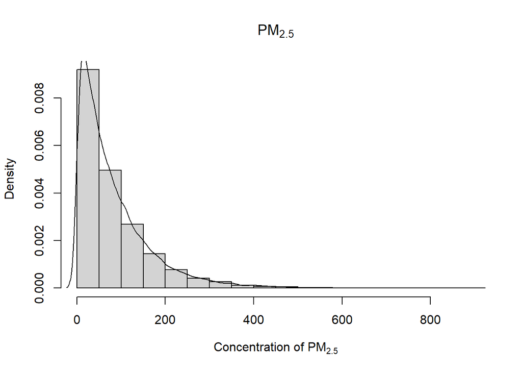

As we can see, the shape of the distribution is very similar to an exponential distribution. In addition, the shape of the distribution is very similar to the shape of the superimposed line which shows the density of an exponential distribution. This all suggests that the PM2.5 concentration is exponentially distributed or very close to being. This is be further proven with the following QQ plot.

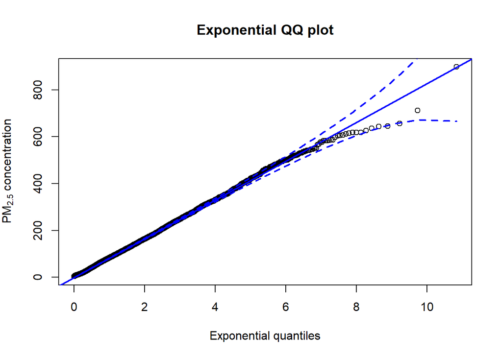

As all the points fall approximately along the line, we can assume the PM2.5 concentration is exponentially distributed.

### Temperature

The mean temperature and standard deviation were 13.74 and 11.51 respectively. The median temperature was 14.8 and mode temperature was 3. Furthermore, the range and interquartile range were 57.3 and 20.4 respectively.

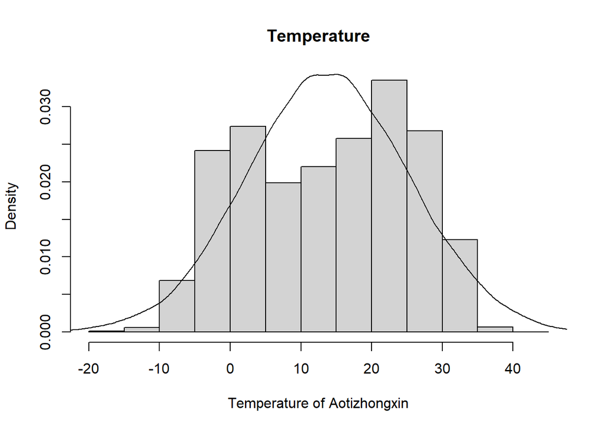

Temperature appears to have a bimodal distribution visually and only roughly seems to have shape as the line which represents the density of a normal distribution with a mean and standard deviation equal to the mean and standard deviation of temperature. Therefore, assuming the distribution solely upon the histogram is difficult. So we use a QQ plot.

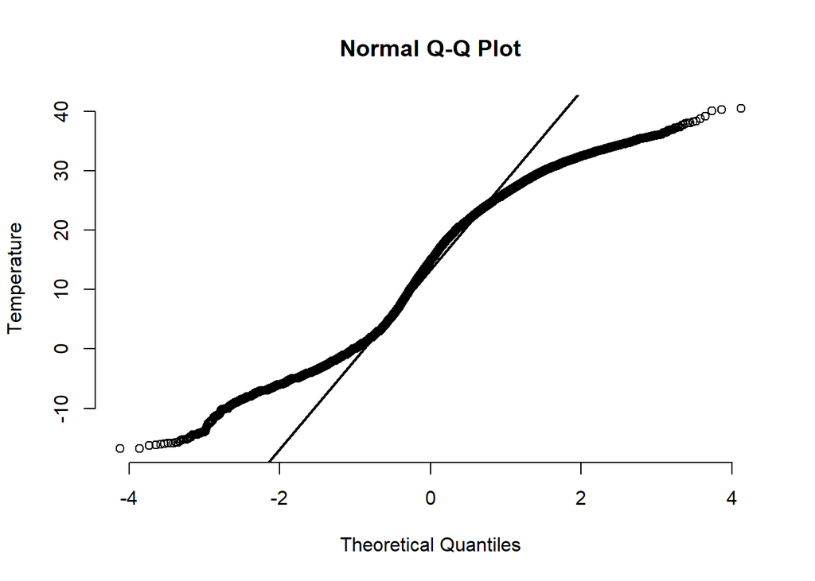

### Rain

The mean and standard deviation of rain/precipitation were 0.07 and 0.89 respectively. Moreover, the median was 0 and the mode was 0. Additionally the range and interquartile range was 46.4 and 0 respectively.

## Relationship between PM2.5, Temperature, Dew Point and Wind Speed

Wind speed, dew point and temperature all vary depending on the time of day. Here we are only focusing on measurements made at 12pm, therefore eliminating the possibility that the data is influenced by time of day and solely upon the variables we are interested in.

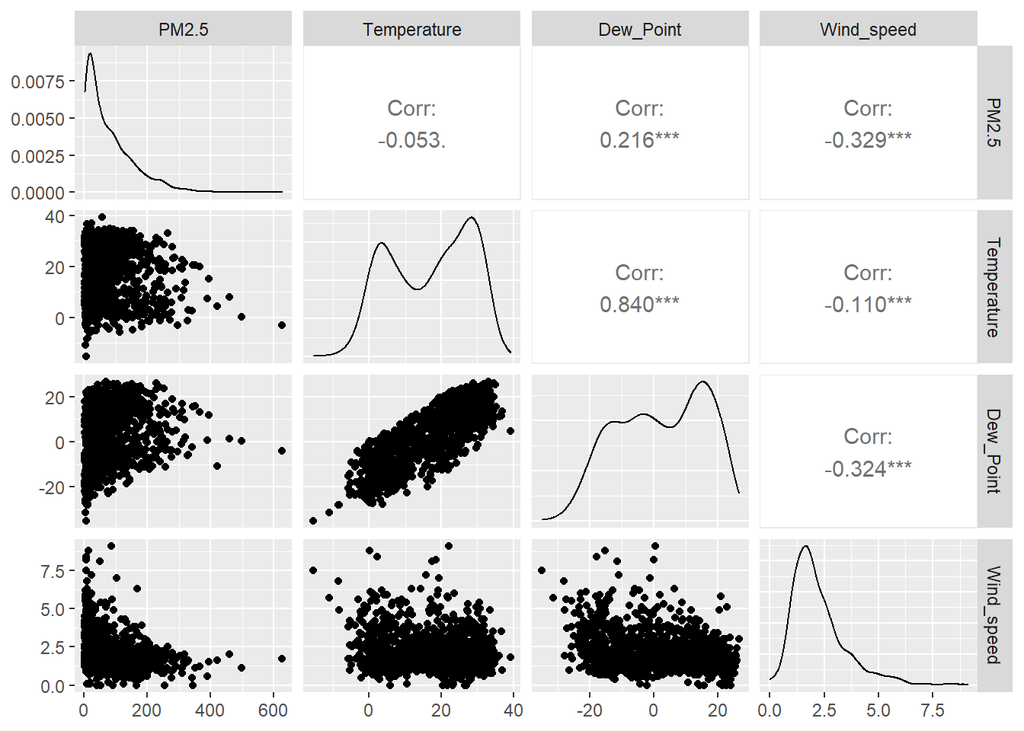

#### PM2.5 and Temperature

Visually the relationship between PM2.5 and temperature seem to have no linear correlation. Moreover the sample correlation coefficient has a value of - 0.053. This is extremely close to 0 which further indicates no linear relationship between the PM2.5 concentration and temperature.

#### PM2.5 and Dew Point

Similar to temperature, there appears to be no linear correlation between PM2.5 and dew point. This is strengthened by the fact that the sample correlation coefficient has value of 0.216 which is again is close to 0 indicating no linear correlation.

#### Temperature and Dew Point

Visually there appears to be a strong positive linear correlation between temperature and dew point ; this is confirmed by its sample correlation coefficient value of 0.840 which is close to 1 which indicates a strong positive linear correlation.

#### Temperature and wind speed

There seems to be no linear correlation between temperature and wind speed. A correlation coefficient value of -0.110 confirms this.

#### Wind speed and Dew point

There is no linear correlation between wind speed and dew point ; the correlation coefficient value of -0.324 substantiates the lack of linear correlation between wind speed and dew point.

### Investigation into how PM2.5 levels differ by year, and by occurrence of rainfall

#### How PM2.5 levels differ by year

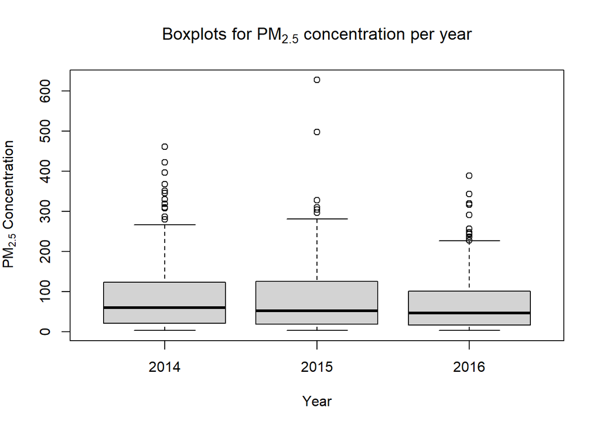

The median PM2.5 concentration appears to decrease from 2014 to 2016. It reduced from60 to 46. This could be a result of China’s State Council creating a pollution reduction target.

#### How PM2.5 levels differ by occurence of rain fall

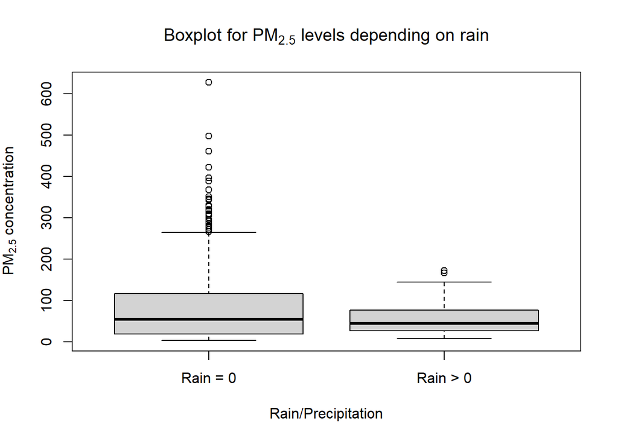

Now we would to test whether the variability of PM2.5 concentration is significantly lower when it is raining. Using the F test to compare two variances requires both sets of data to be normally distributed. Firstly PM2.5 concentration when raining seems to be normally distributed which can be seen by the QQ plot.

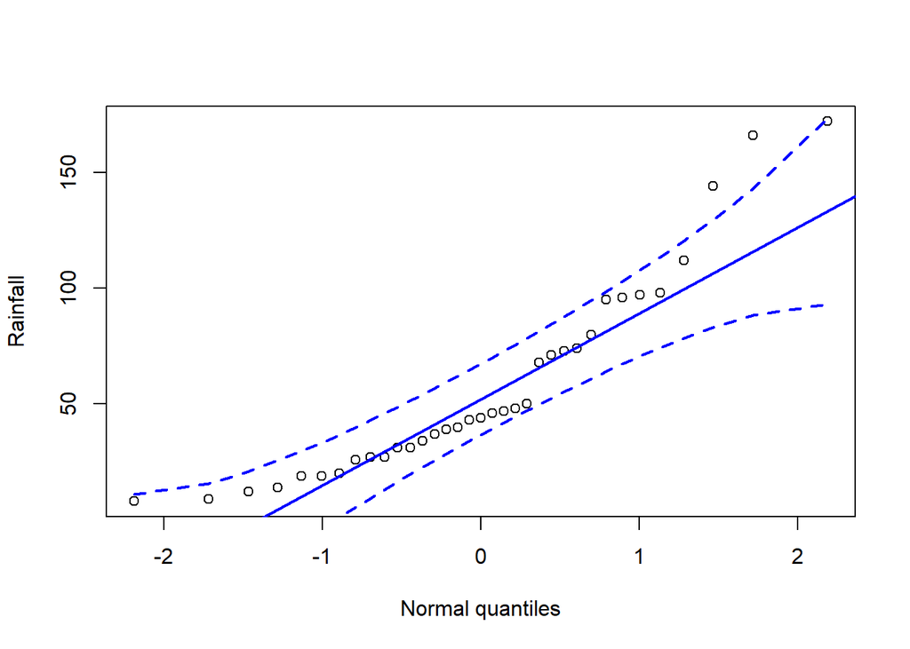

As seen above, the vast majority of points fall approximately along the reference line meaning we can assume normality.

For PM2.5 concentration when not raining, the distribution appears to be exponential as seen by the histogram.

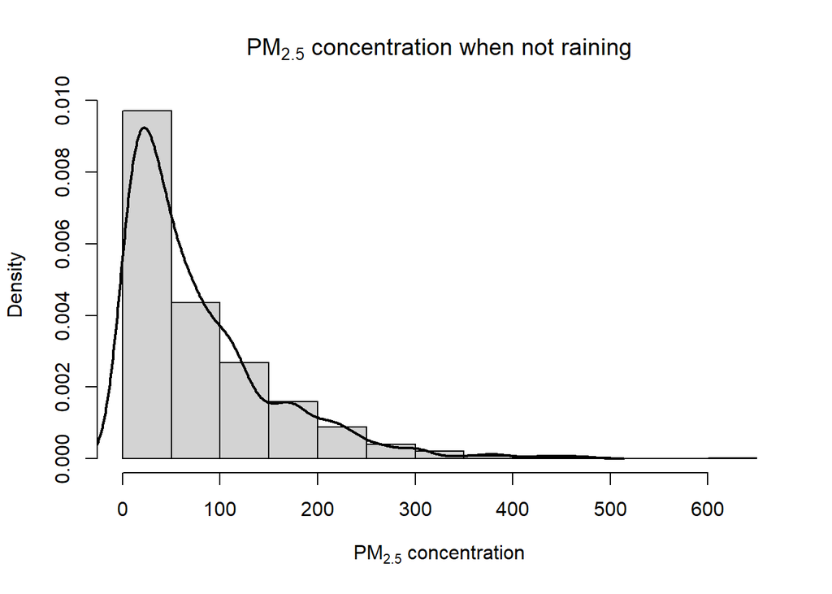

However, the sample size of PM2.5 concentration when not raining is large enough to ignore its distribution.

Suppose that $\sigma^2_\text{rain}$ and $\sigma^2_\text{norain}$ are the variances of the PM2.5 concentrations when it is raining and when it is not raining, respectively. A F test of $\sigma^2_\text{rain} = \sigma^2_\text{norain}$ versus $\sigma^2_\text{rain} < \sigma^2_\text{norain}$ has a test statistic of 0.29658, with corresponding $p$-value of 2.511e-05. At a 10% significance level, 2.511e-05 is less than 0.1 therefore there is sufficient evidence to reject the null hypothesis suggesting the variance of PM2.5 concentration when raining is less than the variance of PM2.5 concentration when it is not raining.

### Dependence of PM2.5 concentration on other pollutants

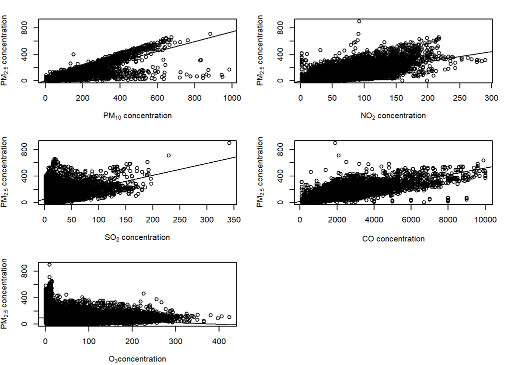

To begin with, PM2.5 and PM10 concentration seem to have a strong positive linear correlation. They have a pearson correlation coefficient value of 0.88 which confirms the strong positive linear correlation as it very close to 1. This suggests as the concentration of PM10 rises so does the concentration of PM2.5.

PM2.5 and NO2 concentration also display a positive linear correlation but seems to be weaker than then correlation between PM2.5 and PM10. A value of 0.69 for the pearson correlation coefficient bolsters both the fact that PM2.5 and NO2 concentration have a positive correlation and that the correlation is weaker than the correlation between PM2.5 and PM10.

PM2.5 and SO2 concentration displays a weak linear correlation. A value of 0.48 for the pearson correlation coefficient confirms the weak positive correlation between PM2.5 and S02 concentration.

PM2.5 and CO concentration display a strong positive linear correlation and has a value of 0.79 for the pearson correlation coefficient. This is stronger than the correlation between PM2.5 and both SO2 and NO2 but weaker than PM10.

Visually, there is no and a very weak negative correlation between PM2.5 and o3 concentration. A pearson correlation coefficient value of -0.17 supports the fact that there no correlation between them as the value is very close to 0.

To conclude all the other pollutants apart from o3 seem to influence the concentration of PM2.5 ; the concentration of PM2.5 rises as the concentration of these pollutants increase. In particular, PM10 has the strongest positive linear correlation with PM2.5. This suggests that PM2.5 concentration is dependent on PM10 concentration the most of out all the other pollutants and a rise in the concentration of PM10 will cause the biggest rise in the concentration of PM2.5.

### Comparing data about PM2.5 at Dingling with Aotizhongxin

Both samples appear to be exponential distributed which can be seen through the following histograms.

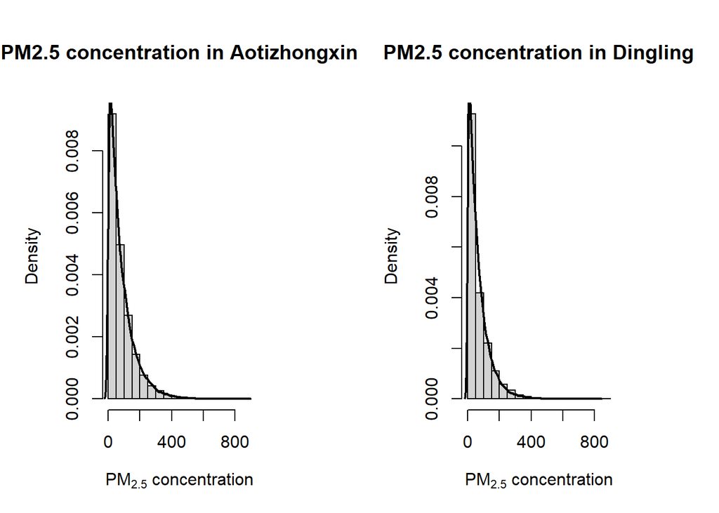

The T - test requires both samples to be normally distributed to compare the means. However, both sample sizes are large enough to ignore the distribution of the data.

The p - value obtained from the Welch T - test was less than 2.2e-16, which is obviously less than 0.05. This suggests there is sufficient evidence to reject the null hypothesis and accept the alternative hypothesis meaning the true difference in means is not equal to 0.

Like the T test, an F test requires both sets of data to be normally distributed. However, both sample sizes are large enough to ignore the distribution of the data sets.

The F test gives us a p-value of less than 2.2e-16. This is clearly less than 0.05 and hence there is sufficient evidence to reject the null hypothesis and accept the alternative hypothesis. Therefore the true ratio of variances is not equal to 1.

# Conclusion

Moreover when discussing PM2.5, temperature, dew point and wind speed, there appears to be no correlation between almost any of these variables. The exception being the strong positive linear correlation between temperature and dew point.

Out of PM10, SO2, NO2, CO and O3, o3 is the only gas that has no linear correlation with PM2.5. PM10 has the strongest positive linear correlation with PM2.5 followed by CO, then NO2 and finally SO2.

Finally there is a significant difference between both the mean and variance of PM2.5 concentration in Aotizhongxin and Dingling.

One limitation is this data is from 2014 to 2016 and hence relevant for that time period. Therefore, any findings found for report may not be relevant in 2021. Therefore, repeating this report with data from 2018 - 2020 may provide more accurate data which is not outdated.

A second limitation concerns the relationship between PM10 and PM2.5 concentration. As shown above they have a strong positive linear correlation. However, this correlation does not imply that PM10 concentration has any direct or indirect upon PM2.5 concentration as correlation does not imply causation.

## Appendix

The R code for producing the results and plots in this report is as follows.

```r
dat <- read.csv("pollutionData.csv")
my_mode <- function(x) {
  unique_x <- unique(x)
  tabulate_x <- tabulate(match(x, unique_x))
  unique_x[tabulate_x == max(tabulate_x)]
}
PM25 <- dat$PM2.5
mean_pm25 <- round(mean(PM25,na.rm=TRUE),digit=2)
sd_pm25 <- round(sd(PM25,na.rm=TRUE),digit=2)
median_pm25 <-round(median(PM25,na.rm=T),digit=2)
mode_pm25 <- my_mode(na.omit(PM25))
rpm25 <- range(PM25,na.rm=T)
range_pm25 <- rpm25[2] - rpm25[1]
iqr_pm25 <- IQR(PM25,na.rm=T)
library(carData)
library(car)
hist(PM25,main=expression("PM"[2.5]),freq=F,
     xlab=expression("Concentration of PM"[2.5]))
pm25_exp <- rexp(length(PM25),rate=1/mean_pm25)
lines(density(pm25_exp),lwd=1)
qqPlot(PM25,'exp',grid=F,id=F,
       main='Exponential QQ plot',
       ylab=expression('PM'['2.5']* ' concentration'),
       xlab='Exponential quantiles')
temp <- dat$TEMP
mean_temp <- round(mean(temp,na.rm=TRUE),digit=2)
sd_temp <- round(sd(temp,na.rm=TRUE),digit=2)
median_temp <-round(median(temp,na.rm=TRUE),digit=2)
mode_temp <- my_mode(temp)
rtemp <- range(temp,na.rm = TRUE)
range_temp <- rtemp[2] - rtemp[1]
iqr_temp <- IQR(temp,na.rm=TRUE)
hist(temp,main='Temperature',xlab = 'Temperature of Aotizhongxin',freq=F)
temp_norm <- rnorm(length(temp),mean = mean_temp, sd = sd_temp)
lines(density(temp_norm),lwd=1)
qqnorm(temp,pch=1,frame=F,ylab='Temperature')
qqline(temp,col="black",lwd=2)
rain <- dat$RAIN
mean_rain <- round(mean(rain,na.rm=TRUE),digit=2)
sd_rain <- round(sd(rain,na.rm=TRUE),digit=2)
median_rain <- round(median(rain,na.rm = TRUE),digit=2)
mode_rain <- my_mode(rain)
rrain <- range(rain,na.rm = TRUE)
range_rain <- rrain[2] - rrain[1]
iqr_rain <- IQR(rain,na.rm = TRUE)
library(GGally)
dat12 <- subset(dat,hour==12)
PM_2.5 <- dat12$PM2.5
Temperature <- dat12$TEMP
Dew_Point <- dat12$DEWP
Wind_Speed <- dat12$WSPM
data <- data.frame(PM2.5 = PM_2.5,
                   Temperature = Temperature,
                   Dew_Point = Dew_Point,
                   Wind_speed = Wind_Speed)
ggpairs(data)
dat2014 <- subset(dat12,year==2014)
dat2015 <- subset(dat12,year==2015)
dat2016 <- subset(dat12,year==2016)
pm25_2014 <- dat2014$PM2.5
pm25_2015 <- dat2015$PM2.5
pm25_2016 <- dat2016$PM2.5
boxplot(pm25_2014,pm25_2015,pm25_2016,
        main= expression("Boxplots for"*" PM"[2.5]*" concentration per year"),
        names=c("2014","2015","2016"),
        xlab="Year",
        ylab=expression('PM'[2.5]*' Concentration')
        )
med2014 <- median(na.omit(pm25_2014))
med2016 <- median(na.omit(pm25_2016))
rrain0 <- subset(dat12,RAIN==0)
rain0 <- rrain0$PM2.5
rraing <- subset(dat12,RAIN > 0)
raing <- rraing$PM2.5
boxplot(rain0,raing,
        names=c("Rain = 0","Rain > 0"),
        main=expression("Boxplot for"*" PM"[2.5]*" levels depending on rain"),
        ylab= expression('PM'[2.5]*' concentration'),
        xlab = "Rain/Precipitation")

qqPlot(raing,'norm',grid=F,id=F,ylab='Rainfall',xlab='Normal quantiles')
hist(rain0,freq=F,main=expression("PM"[2.5]* " concentration when not raining"),xlab = expression('PM'[2.5]* ' concentration'))
rain0rm <- na.omit(rain0)
abc <- rexp(length(rain0rm),rate=1/mean(rain0rm))
lines(density(abc),lwd=2)
var.test(raing,rain0,alternative='less')
par(mfrow = c(3,2),mar = c(4,4,2,2))

plot(dat$PM10,dat$PM2.5,xlab=expression('PM'[10]*' concentration'),
     ylab=expression('PM'[2.5]*' concentration'))
abline(lm(dat$PM2.5~dat$PM10))

plot(dat$NO2,dat$PM2.5,
     ylab = expression('PM'[2.5]*' concentration'),
     xlab=expression('NO'[2]*' concentration'))
abline(lm(dat$PM2.5~dat$NO2))

plot(dat$SO2,dat$PM2.5,
     ylab = expression('PM'[2.5]*' concentration'),
     xlab = expression('SO'[2]*' concentration'))
abline(lm(dat$PM2.5~dat$SO2))

plot(dat$CO,dat$PM2.5,
     ylab = expression('PM'[2.5]*' concentration'),
     xlab='CO concentration')
abline(lm(dat$PM2.5~dat$CO))

plot(dat$O3,dat$PM2.5,
     ylab = expression('PM'[2.5]*' concentration'),
     xlab=expression('O'[3]*'concentration'))
abline(lm(dat$PM2.5~dat$O3))
cor.test(dat$PM10,dat$PM2.5)
cor.test(dat$NO2,dat$PM2.5)
cor.test(dat$SO2,dat$PM2.5)
cor.test(dat$CO,dat$PM2.5)
cor.test(dat$O3,dat$PM2.5)
datling <- read.csv("PopulationData_Dingling.csv")
par(mfrow=c(1,2),mar=c(5,5,5,5))
gg <- na.omit(dat$PM2.5)
sam1 <- rexp(length(gg),1/mean(gg))
hist(gg,freq=F,main="PM2.5 concentration in Aotizhongxin",xlab=expression('PM'[2.5]*' concentration'))
lines(density(sam1),lwd=2)

bb <- na.omit(datling$PM2.5)
sam2 <- rexp(length(bb),1/mean(bb))
hist(bb,freq=F,main="PM2.5 concentration in Dingling",xlab=expression('PM'[2.5]*' concentration'))
lines(density(sam2),lwd=2)

t.test(dat$PM2.5,datling$PM2.5)

var.test(dat$PM2.5,datling$PM2.5,alternative = 'two.sided')
```